# Determining Unfairness in Medicaid Reimbursement Rates

# Between Idaho and the Nation

by Robert Barnett on November 26, 2023

1. Background
2. Investigation
   1. Hypothesis
3. Loading the Data
4. Cleaning the Data
5. Exploratory Data Analysis
6. Conclusions
7. Sources

## Background

Medicaid has a reputation for underpaying healthcare providers for covered services. In a blog article from *The Commonwealth Fund* titled "Medicaid Reimbursement Rates Are a Racial Justice Issue", the authors discuss how reimbursement rates affect access and quality of care for underprivileged groups. They highlight that Medicaid reimbursement rates are significantly lower than Medicare and commercial insurance rates which creates a financial disincentive for providers to accept Medicaid patients which affects availability and quality of care. It draws many connections between Medicaid's low reimbursement rates and low quality of care.

A lawsuit was filed in 2021 by the National Association of Chain Drug Stores (NACDS), National Community Pharmacists Association (NCPA), and the Washington State Pharmacy Association versus the Secretary of the United States Department of Health and Human Services (HHS), and the Centers for Medicare and Medicaid Services (CMS). The plaintiffs claim that Medicaid does not adequatly reimburse pharmacies for the services they provide to beneficiaries and that their reimbursement rates are the lowest in the country which violates federal law. They allege that the rates are below their actual costs which has caused significant harm to rural and independent pharmacies. Their case particularly focuses on the dispensing fee portion of their reimbursement rates, which covers costs associated with dispensing a medication, such as payroll, utilities, rent, supplies, etc.

Medicaid underpayment has been a long concern in the legislative landscape as well. In 2006, CMS proposed a rule to implement provisions of the Deficit Reduction Act that would reduce Medicaid reimbursements for prescriptions. The rule would redefine the cost basis for reimbursements. HHS forecasted that the change would adversely affect revenue for small pharmacies in low-income areas where the concentrations of Medicaid beneficiaries was high. HHS advised that small pharmacies purchase lower-cost drugs to mitigate the burden. However, that was already a best practice among all pharmacies. HHS also released a report finding that 19 of the 25 highest expenditure drugs would result in underpayments under the new rule. Pharmacy groups attempted to work with lawmakers to draft revisions to change the cost-basis to a metric that was tangible for pharmacies, but the CMS administrator dismissed concerns in favor of waiting to see how things turned out.  
In my peronal experience working in Idaho pharmacies, I have had many opportunities to examine rates of reimbursement from many payors, including Medicaid. There have been many times that I have had to challenge reimbursements that were below cost. In many situations, the discrepancies in pricing were the result of Idaho's Medicaid program using outdated database information. In one case, a medication was unavailable due to a national backorder except for one NDC. As that price increased, Medicaid continued to reimburse at the outdated rate. These experiences are the initiators of my concern for Medicaid underpayments.

## Investigation

The two datasets were obtained from Medicaid's website as publically available datasets. The NADAC dataset contains information used to expand the information in the Drug Utilization dataset based on NDC as a key. The exploration of the dataset will filter out unnecessary data and then compare reimbursement rates to evaluate a null hypothesis.

### *Definitions*

The following terms appear within the datasets in this investigation:

- `ndc` - National Drug Code. A concatenation of three codes that indicate the manufacturer, the drug, and the package size. It is a unique identifier of a product offering.
- `state` - The two-letter acronym for a state in the United States of America. Additionally, XX is used to indicate the nation as a whole.
- `product_name` - The common name of the drug.
- `units_reimbursed` - The total number of units, based on unit of measurement, that were dispensed.
- `number_of_prescriptions` - The total number of prescriptions that were filled for the NDC.
- `total_amount_reimbursed` - The total value of reimbursement paid to the pharmacy.
- `NDC Description` - in the NADAC table, this is the full product name, which includes the drug name, strength, and dosage form. It becomes renamed to `drug`.
- `Pricing_Unit` - This is the unit of measurement, which can be `EA`, `ML`, OR `GM` for eaches, volume, or mass, respectively. This investigation will omit volume and mass dispensings since those can have variable rates or reimbursement (either full pack or partial pack payments).
- `Classification_for_Rate_Setting` - This separates between brand or generic medications. They are typically priced on two separate scales. If a generic was reimbursed at the same scale as a brand drug, it could become cost-prohibitive to stock. Conversely, if a brand was priced on the same scale as a generic, it could become astronomical in price.

### *Hypothesis*

- **Null Hypothesis**: There is no significant difference in reimbursement rates between Idaho and the nation.
- **Alternate Hypothesis**: There is a significant difference in reimbursement rates between Idaho and the nation.
- **α** = 0.05
- **Z-Critical** = 1.96

## Loading the Data

```python
# import libraries
import pandas as pd
import matplotlib.pyplot as plt
import numpy as np
from scipy import stats
from scipy.stats import zscore
plt.rcParams['figure.figsize'] = [14,5]
```

```python
# read the datasets into dataframes
du = pd.read_csv('DrugUtilization2022_updated.csv')
nadac = pd.read_csv('nadac-national-average-drug-acquisition-cost-2022.csv')
```

```python
du.head()
```

|  | utilization_type | state | ndc | labeler_code | product_code | package_size | year | quarter | suppression_used | product_name | units_reimbursed | number_of_prescriptions | total_amount_reimbursed | medicaid_amount_reimbursed | non_medicaid_amount_reimbursed |
| --- | --- | --- | --- | --- | --- | --- | --- | --- | --- | --- | --- | --- | --- | --- | --- |
| 0 | FFSU | AK | 2143380 | 2 | 1433 | 80 | 2022 | 4 | False | TRULICITY | 481.0 | 201.0 | 205175.49 | 198526.95 | 6648.54 |
| 1 | FFSU | AK | 2143401 | 2 | 1434 | 1 | 2022 | 4 | True | TRULICITY | NaN | NaN | NaN | NaN | NaN |
| 2 | FFSU | AK | 2143480 | 2 | 1434 | 80 | 2022 | 4 | False | TRULICITY | 650.0 | 232.0 | 277356.35 | 269046.67 | 8309.68 |
| 3 | FFSU | AK | 2143611 | 2 | 1436 | 11 | 2022 | 4 | False | EMGALITY P | 26.0 | 25.0 | 16642.78 | 16642.78 | 0.00 |
| 4 | FFSU | AK | 2144511 | 2 | 1445 | 11 | 2022 | 4 | False | TALTZ AUTO | 26.0 | 23.0 | 164678.63 | 164678.63 | 0.00 |

```python
nadac.head()
```

|  | NDC Description | NDC | NADAC_Per_Unit | Effective_Date | Pricing_Unit | Pharmacy_Type_Indicator | OTC | Explanation_Code | Classification_for_Rate_Setting | Corresponding_Generic_Drug_NADAC_Per_Unit | Corresponding_Generic_Drug_Effective_Date | As of Date |
| --- | --- | --- | --- | --- | --- | --- | --- | --- | --- | --- | --- | --- |
| 0 | 12HR NASAL DECONGEST ER 120 MG | 24385005452 | 0.29366 | 12/22/2021 | EA | C/I | Y | 1 | G | NaN | NaN | 01/05/2022 |
| 1 | 12HR NASAL DECONGEST ER 120 MG | 70000047501 | 0.29366 | 12/22/2021 | EA | C/I | Y | 1 | G | NaN | NaN | 01/05/2022 |
| 2 | 24H NASAL ALLERGY 55 MCG SPRAY | 46122038576 | 0.78092 | 12/22/2021 | ML | C/I | Y | 1, 5 | G | NaN | NaN | 01/05/2022 |
| 3 | 24HR ALLERGY(LEVOCETIRZN) 5 MG | 70000036201 | 0.19147 | 12/22/2021 | EA | C/I | Y | 1 | G | NaN | NaN | 01/05/2022 |
| 4 | 24HR ALLERGY(LEVOCETIRZN) 5 MG | 70000036202 | 0.19147 | 12/22/2021 | EA | C/I | Y | 1 | G | NaN | NaN | 01/05/2022 |

```python
# check for NDC formatting (should be 11-digit fixed length)
nadac['NDC'].sort_values(ascending=False).tail()
```

```
800812     2143380
247922     2143380
876560     2143380
1210250    2143380
123337     2143380
Name: NDC, dtype: int64
```

```python
du.info()
```

```
<class 'pandas.core.frame.DataFrame'>
RangeIndex: 5087596 entries, 0 to 5087595
Data columns (total 15 columns):
 #   Column                          Dtype
---  ------                          -----
 0   utilization_type                object
 1   state                           object
 2   ndc                             int64
 3   labeler_code                    int64
 4   product_code                    int64
 5   package_size                    int64
 6   year                            int64
 7   quarter                         int64
 8   suppression_used                bool
 9   product_name                    object
 10  units_reimbursed                float64
 11  number_of_prescriptions         float64
 12  total_amount_reimbursed         float64
 13  medicaid_amount_reimbursed      float64
 14  non_medicaid_amount_reimbursed  float64
dtypes: bool(1), float64(5), int64(6), object(3)
memory usage: 548.3+ MB
```

```python
nadac.info()
```

```
<class 'pandas.core.frame.DataFrame'>
RangeIndex: 1315703 entries, 0 to 1315702
Data columns (total 12 columns):
 #   Column                                     Non-Null Count    Dtype
---  ------                                     --------------    -----
 0   NDC Description                            1315703 non-null  object
 1   NDC                                        1315703 non-null  int64
 2   NADAC_Per_Unit                             1315703 non-null  float64
 3   Effective_Date                             1315703 non-null  object
 4   Pricing_Unit                               1315703 non-null  object
 5   Pharmacy_Type_Indicator                    1315703 non-null  object
 6   OTC                                        1315703 non-null  object
 7   Explanation_Code                           1315703 non-null  object
 8   Classification_for_Rate_Setting            1315703 non-null  object
 9   Corresponding_Generic_Drug_NADAC_Per_Unit  32900 non-null    float64
 10  Corresponding_Generic_Drug_Effective_Date  32900 non-null    object
 11  As of Date                                 1315703 non-null  object
dtypes: float64(2), int64(1), object(9)
memory usage: 120.5+ MB
```

Back to Top

## Cleaning the Data

### *NADAC Table*

- The column `NDC` is int64 type. As such, it has lost the leading zeroes. This will be cast as string and filled with leading zeros.
- Rename `NDC` to `ndc` and `NDC Description` to `drug`
- Remove duplicates of `NDC`

```python
# cast ndc and NDC cols as strings
du['ndc'] = du['ndc'].astype(str)
nadac['NDC'] = nadac['NDC'].astype(str)

# fill in leading zeroes
du['ndc'] = du['ndc'].str.zfill(11)
nadac['NDC'] = nadac['NDC'].str.zfill(11)

# rename columns
nadac = nadac.rename(columns={'NDC': 'ndc', 'NDC Description': 'drug'})

# create calculated reimbursement per unit column
du['reimbursement_per_unit'] = du['total_amount_reimbursed'] / du['units_reimbursed']

# drop unnecessary columns
du = du.drop(columns=['utilization_type', 'labeler_code','product_code','package_size', 'year',
                      'suppression_used', 'medicaid_amount_reimbursed',
                      'non_medicaid_amount_reimbursed'], axis=1)
nadac = nadac.drop(columns=['NADAC_Per_Unit', 'Effective_Date', 'Pharmacy_Type_Indicator',
                            'Explanation_Code', 'Corresponding_Generic_Drug_NADAC_Per_Unit',
                            'Corresponding_Generic_Drug_Effective_Date', 'As of Date'])
# drop duplicates of ndc
nadac = nadac.drop_duplicates(subset=['ndc'])

# Drop NaN entries
du = du.dropna()
```

```python
# verify ndcs are unique
nadac['ndc'].value_counts().sort_values(ascending=False)
```

```
ndc
24385005452    1
31722055760    1
70000036202    1
51672206200    1
46122006271    1
              ..
00078095325    1
29300011805    1
29300011810    1
16714098602    1
70710135003    1
Name: count, Length: 28199, dtype: int64
```

Back to Top

## Exploratory Data Analysis

```python
# merge the drug info into the utilization info on ndc, many to one
data = du.merge(nadac, on='ndc', how='left', validate='m:1')

# select rows that are not for over-the-counter medications
data = data[data.OTC == 'N']

# selecting rows for the 1st quarter
data = data[data.quarter == 1]

# select only for 'EA' units of measure
data = data[data.Pricing_Unit == 'EA']

# create a calculated column for z-score of the reimbursement rates grouped by NDC
data['z_score_reimburse_rate'] = data.groupby(['ndc']).reimbursement_per_unit.transform(lambda x : zscore(x,ddof=1))

# separate brands and generics
data = data.dropna()
generic = data[data['Classification_for_Rate_Setting'] == 'G']
brand = data[data['Classification_for_Rate_Setting'] != 'G']

# z-scores filterd for ID and XX (nation)
id_generic = generic.loc[generic.state == 'ID'].sort_values(by=['z_score_reimburse_rate'], ascending=True)
id_brand = generic.loc[generic.state == 'XX'].sort_values(by=['z_score_reimburse_rate'], ascending=True)
xx_generic = brand.loc[brand.state == 'ID'].sort_values(by=['z_score_reimburse_rate'], ascending=True)
xx_brand = brand.loc[brand.state == 'XX'].sort_values(by=['z_score_reimburse_rate'], ascending=True)
```

```python
# find top 5 brands and generics
generic.sort_values(by='number_of_prescriptions', ascending=False).head(10)
```

|  | state | ndc | quarter | product_name | units_reimbursed | number_of_prescriptions | total_amount_reimbursed | reimbursement_per_unit | drug | Pricing_Unit | OTC | Classification_for_Rate_Setting | z_score_reimburse_rate |
| --- | --- | --- | --- | --- | --- | --- | --- | --- | --- | --- | --- | --- | --- |
| 1491172 | XX | 69452015120 | 1 | Ergocalcif | 3.277511e+06 | 593522.0 | 1579224.10 | 0.481836 | VITAMIN D2 1.25 MG(50,000 UNIT) | EA | N | G | -0.444039 |
| 1481520 | XX | 64380073706 | 1 | Ergocalcif | 2.430350e+06 | 510335.0 | 1639357.12 | 0.674535 | VITAMIN D2 1.25 MG(50,000 UNIT) | EA | N | G | -0.307259 |
| 1487346 | XX | 68180072103 | 1 | Amlodipine | 1.436195e+07 | 276901.0 | 1270083.95 | 0.088434 | AMLODIPINE BESYLATE 10 MG TAB | EA | N | G | -0.801163 |
| 1463859 | XX | 42806054701 | 1 | Ergocalcif | 1.448071e+06 | 275804.0 | 661235.05 | 0.456632 | VITAMIN D2 1.25 MG(50,000 UNIT) | EA | N | G | -0.976930 |
| 1481519 | XX | 64380073706 | 1 | Ergocalcif | 1.419137e+06 | 275336.0 | 3096970.81 | 2.182291 | VITAMIN D2 1.25 MG(50,000 UNIT) | EA | N | G | -0.078643 |
| 1487617 | XX | 68180098003 | 1 | Lisinopril | 1.223957e+07 | 251955.0 | 1004605.95 | 0.082079 | LISINOPRIL 10 MG TABLET | EA | N | G | -0.419357 |
| 1473469 | XX | 57237007710 | 1 | ONDANSETRO | 3.878243e+06 | 246673.0 | 1960065.98 | 0.505401 | ONDANSETRON ODT 4 MG TABLET | EA | N | G | -0.230069 |
| 1483297 | XX | 65862039010 | 1 | ONDANSETRO | 4.005670e+06 | 243752.0 | 2669980.29 | 0.666550 | ONDANSETRON ODT 4 MG TABLET | EA | N | G | -0.176314 |
| 1440412 | XX | 00054018913 | 1 | Buprenorph | 5.889023e+06 | 242977.0 | 15206056.50 | 2.582102 | BUPRENORPHINE-NALOXONE 8-2 MG SL TABLET | EA | N | G | 0.872016 |
| 1471859 | XX | 52817033200 | 1 | Cyclobenza | 1.107585e+07 | 238758.0 | 1258908.78 | 0.113662 | CYCLOBENZAPRINE 10 MG TABLET | EA | N | G | -0.540867 |

```python
brand.sort_values(by='number_of_prescriptions', ascending=False).head(10)
```

|  | state | ndc | quarter | product_name | units_reimbursed | number_of_prescriptions | total_amount_reimbursed | reimbursement_per_unit | drug | Pricing_Unit | OTC | Classification_for_Rate_Setting | z_score_reimburse_rate |
| --- | --- | --- | --- | --- | --- | --- | --- | --- | --- | --- | --- | --- | --- |
| 1456134 | XX | 12496120803 | 1 | Suboxone S | 12787928.90 | 411930.0 | 1.139631e+08 | 8.911774 | SUBOXONE 8 MG-2 MG SL FILM | EA | N | B | -0.143334 |
| 1456135 | XX | 12496120803 | 1 | Suboxone S | 11574839.00 | 311835.0 | 1.000357e+08 | 8.642511 | SUBOXONE 8 MG-2 MG SL FILM | EA | N | B | -0.216610 |
| 1439291 | XX | 00003089421 | 1 | Eliquis | 16715378.39 | 260079.0 | 1.435219e+08 | 8.586217 | ELIQUIS 5 MG TABLET | EA | N | B | 0.251124 |
| 1477641 | XX | 61958250101 | 1 | Biktarvy | 3663554.00 | 119550.0 | 4.284315e+08 | 116.944224 | BIKTARVY 50-200-25 MG TABLET | EA | N | B | 0.317613 |
| 1451739 | XX | 00597015330 | 1 | Jardiance | 4494469.00 | 118463.0 | 8.312719e+07 | 18.495441 | JARDIANCE 25 MG TABLET | EA | N | B | 0.292796 |
| 1439290 | XX | 00003089421 | 1 | Eliquis | 7591825.50 | 113790.0 | 6.445947e+07 | 8.490642 | ELIQUIS 5 MG TABLET | EA | N | B | 0.153114 |
| 1474592 | XX | 59417010310 | 1 | VYVANSE 30 | 3379354.30 | 113721.0 | 3.772685e+07 | 11.163924 | VYVANSE 30 MG CAPSULE | EA | N | B | 0.058098 |
| 1474594 | XX | 59417010410 | 1 | VYVANSE 40 | 3118803.00 | 104713.0 | 3.474317e+07 | 11.139905 | VYVANSE 40 MG CAPSULE | EA | N | B | 0.034736 |
| 1439427 | XX | 00006027731 | 1 | JANUVIA 10 | 3826944.00 | 101530.0 | 6.532624e+07 | 17.070079 | JANUVIA 100 MG TABLET | EA | N | B | -0.022895 |
| 2568357 | WV | 12496120803 | 1 | SUBOXONE 8 | 1768844.00 | 97689.0 | 1.614683e+07 | 9.128462 | SUBOXONE 8 MG-2 MG SL FILM | EA | N | B | -0.084366 |

```python
# choosing 1 NDC for 5 different generic and brand drugs of the top prescribed count
# Ergocalciferol, Amlodipine, Lisinopril, Ondansetron, and Cyclobenzaprine
top5_generic = ['69452015120','68180072103','68180098003','57237007710','52817033200']

# Eliquis, Biktarvy, Jardiance, Vyvanse, Januvia
top5_brand = ['00003089421', '61958250101', '00597015330', '59417010310', '00006027731']
```

```python
# create list of drug names
top5_generic_drugs = []
top5_brand_drugs = []
for i in top5_generic:
    drug_name = nadac.loc[nadac['ndc'] == i, 'drug'].item()
    top5_generic_drugs.append(drug_name)
for i in top5_brand:
    drug_name = nadac.loc[nadac['ndc'] == i, 'drug'].item()
    top5_brand_drugs.append(drug_name)

print(top5_generic_drugs)
print(top5_brand_drugs)
```

```
['VITAMIN D2 1.25 MG(50,000 UNIT)', 'AMLODIPINE BESYLATE 10 MG TAB', 'LISINOPRIL 10 MG TABLET', 'ONDANSETRON ODT 4 MG TABLET', 'CYCLOBENZAPRINE 10 MG TABLET']
['ELIQUIS 5 MG TABLET', 'BIKTARVY 50-200-25 MG TABLET', 'JARDIANCE 25 MG TABLET', 'VYVANSE 30 MG CAPSULE', 'JANUVIA 100 MG TABLET']
```

```python
# Functions
def plot_hist(top_5, bar_color):
    '''
    input a list of NDCs
    iterates over the list and constructs a dataframe of that NDC
    fetches the drug name from the nadac dataset
    constructs a histogram for 'reimbursement_per_unit' for each row of the iterated NDC
    where each row should represent one state
    '''
    for i in top_5:
        df = data[data.ndc == i]
        drug_name = nadac.loc[nadac['ndc'] == i, 'drug'].item()
        plt.hist(df['reimbursement_per_unit'], bins=14, color = bar_color, lw=2, ec='black')
        plt.title(f'Distribution of Reimbursement Rates for NDC: {i}\n{drug_name}')
        plt.show()

def multiplot_hist(top_5, max_lim):
    '''
    input a list of NDCs, max limit for x axis
    iterates over the list and fetches drug names
    sets the bin count and axis range based on max_lim
    creates a histogram for each NDC's reimbursement_per_unit on one plot
    '''
    drugs = []
    for i in top_5:
        drug_name = nadac.loc[nadac['ndc'] == i, 'drug'].item()
        drugs.append(drug_name)
    bins = np.linspace(0, max_lim, 200)
    plt.hist(data[data.ndc == top_5[0]]['reimbursement_per_unit'], bins, alpha=0.5, label=drugs[0])
    plt.hist(data[data.ndc == top_5[1]]['reimbursement_per_unit'], bins, alpha=0.5, label=drugs[1])
    plt.hist(data[data.ndc == top_5[2]]['reimbursement_per_unit'], bins, alpha=0.5, label=drugs[2])
    plt.hist(data[data.ndc == top_5[3]]['reimbursement_per_unit'], bins, alpha=0.5, label=drugs[3])
    plt.hist(data[data.ndc == top_5[4]]['reimbursement_per_unit'], bins, alpha=0.5, label=drugs[4])
    plt.legend(loc='upper right')
    plt.title('Distribution of Medicaid Reimbursement Rates for Selected Medications in Each State')
    plt.show()

def multiplot_z(top_5):
    '''
    input a list of NDCs
    iterates over the list and fetches drug names
    creates a histogram for each NDC's z-score on one plot
    '''
    drugs = []
    for i in top_5:
        drug_name = nadac.loc[nadac['ndc'] == i, 'drug'].item()
        drugs.append(drug_name)
    bins = np.linspace(-6, 6, 50)
    plt.hist(data[data.ndc == top_5[0]]['z_score_reimburse_rate'], bins, alpha=0.5, label=drugs[0])
    plt.hist(data[data.ndc == top_5[1]]['z_score_reimburse_rate'], bins, alpha=0.5, label=drugs[1])
    plt.hist(data[data.ndc == top_5[2]]['z_score_reimburse_rate'], bins, alpha=0.5, label=drugs[2])
    plt.hist(data[data.ndc == top_5[3]]['z_score_reimburse_rate'], bins, alpha=0.5, label=drugs[3])
    plt.hist(data[data.ndc == top_5[4]]['z_score_reimburse_rate'], bins, alpha=0.5, label=drugs[4])
    plt.legend(loc='upper right')
    plt.title('Distribution of Z-Scores for Medicaid Reimbursement Rates for Selected Medications in Each State')
    plt.show()
```

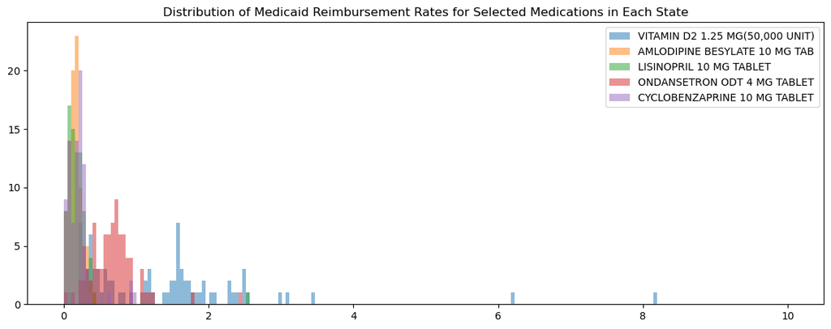

```python
multiplot_hist(top5_generic, 10)
```

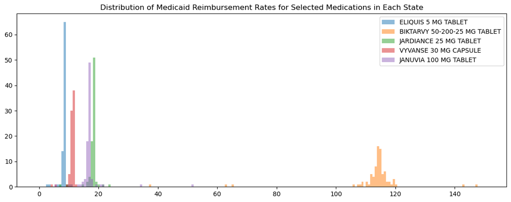

```python
multiplot_hist(top5_brand, 150)
```

```python
# z-score for generics vs idaho
for code, drug in zip(top5_generic, top5_generic_drugs):
    df = data[data.ndc == code]
    df_id = df.loc[df['state'] == 'ID']
    sd = df['reimbursement_per_unit'].std()
    mean = df['reimbursement_per_unit'].mean()
    median = df['reimbursement_per_unit'].median()
    minimum = df['reimbursement_per_unit'].min()
    maximum = df['reimbursement_per_unit'].max()
    id_value = df_id['reimbursement_per_unit'].item()
    z_score = (id_value - mean) / sd

    print(f'Evaluation of Z-Score for Idaho vs the Nation for Reimbursement Rates of\n{drug} (NDC: {code})')
    print(f'Standard Deviation: {sd}')
    print(f'Mean: {mean}')
    print(f'Median: {median}')
    print(f"Idaho's Reimbursement Rate: {id_value}")
    print(f'Z-Score: {z_score}\n')
```

```
Evaluation of Z-Score for Idaho vs the Nation for Reimbursement Rates of
VITAMIN D2 1.25 MG(50,000 UNIT) (NDC: 69452015120)
Standard Deviation: 2.523757757849768
Mean: 1.6024825956367814
Median: 1.2546544732422074
Idaho's Reimbursement Rate: 2.3510710799211654
Z-Score: 0.2966166154243656

Evaluation of Z-Score for Idaho vs the Nation for Reimbursement Rates of
AMLODIPINE BESYLATE 10 MG TAB (NDC: 68180072103)
Standard Deviation: 0.08414409266776365
Mean: 0.15584712284823135
Median: 0.1506278682576673
Idaho's Reimbursement Rate: 0.31061588861588857
Z-Score: 1.8393301402482234

Evaluation of Z-Score for Idaho vs the Nation for Reimbursement Rates of
LISINOPRIL 10 MG TABLET (NDC: 68180098003)
Standard Deviation: 0.2812469795046272
Mean: 0.20002153058803868
Median: 0.151869846153189
Idaho's Reimbursement Rate: 0.3103084029617553
Z-Score: 0.39213531312574385

Evaluation of Z-Score for Idaho vs the Nation for Reimbursement Rates of
ONDANSETRON ODT 4 MG TABLET (NDC: 57237007710)
Standard Deviation: 1.3938958922493099
Mean: 0.8260929529327101
Median: 0.6710890464977625
Idaho's Reimbursement Rate: 0.8338080346403657
Z-Score: 0.005534905261257239

Evaluation of Z-Score for Idaho vs the Nation for Reimbursement Rates of
CYCLOBENZAPRINE 10 MG TABLET (NDC: 52817033200)
Standard Deviation: 0.17727063029363677
Mean: 0.20954226332746978
Median: 0.19394613903415678
Idaho's Reimbursement Rate: 0.252040301356393
Z-Score: 0.23973535807103577
```

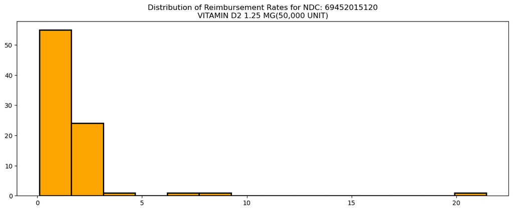

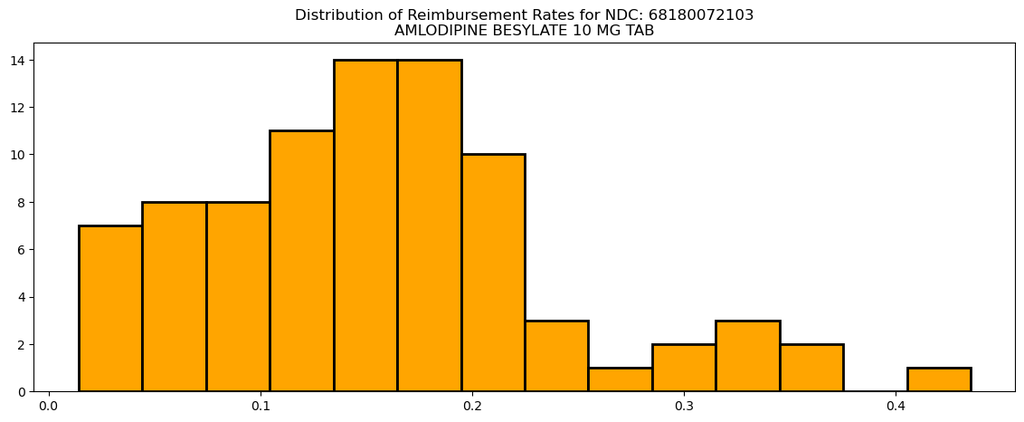

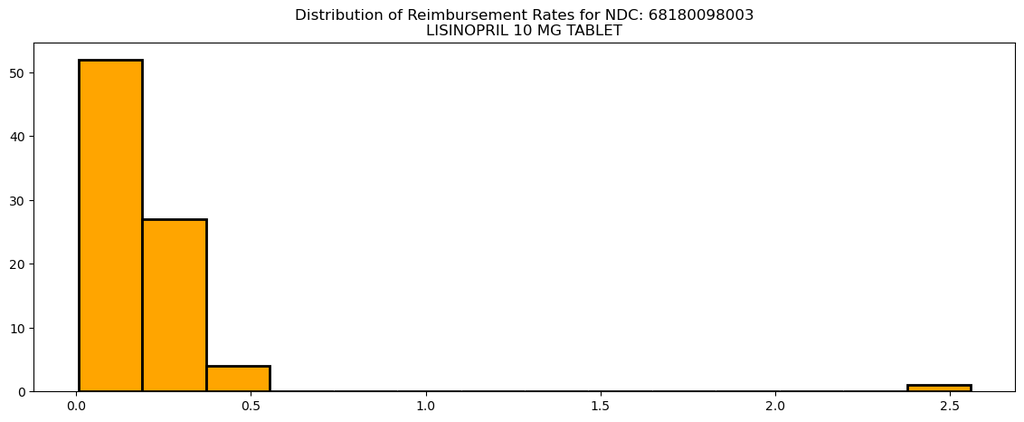

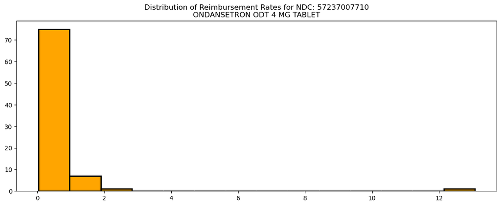

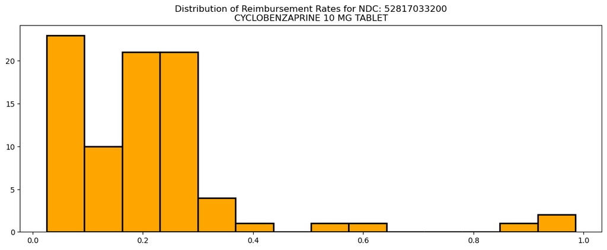

```python
plot_hist(top5_generic, 'orange')
```

```python
# z-score for top dispensed brands vs idaho
for code, drug in zip(top5_brand, top5_brand_drugs):
    df = data[data.ndc == code]
    df_id = df.loc[df['state'] == 'ID']
    sd = df['reimbursement_per_unit'].std()
    mean = df['reimbursement_per_unit'].mean()
    median = df['reimbursement_per_unit'].median()
    minimum = df['reimbursement_per_unit'].min()
    maximum = df['reimbursement_per_unit'].max()
    id_value = df_id['reimbursement_per_unit'].item()
    z_score = (id_value - mean) / sd

    print(f'Evaluation of Z-Score for Idaho vs the Nation for Reimbursement Rates of\n{drug} (NDC: {code})')
    print(f'Standard Deviation: {sd}')
    print(f'Mean: {mean}')
    print(f'Median: {median}')
    print(f"Idaho's Reimbursement Rate: {id_value}")
    print(f'Z-Score: {z_score}\n')
```

```
Evaluation of Z-Score for Idaho vs the Nation for Reimbursement Rates of
ELIQUIS 5 MG TABLET (NDC: 00003089421)
Standard Deviation: 0.9751527138462415
Mean: 8.341332470810668
Median: 8.469146176837356
Idaho's Reimbursement Rate: 8.563529629904323
Z-Score: 0.22785883271272972

Evaluation of Z-Score for Idaho vs the Nation for Reimbursement Rates of
BIKTARVY 50-200-25 MG TABLET (NDC: 61958250101)
Standard Deviation: 12.851538616614558
Mean: 112.86241203593191
Median: 114.38348333860209
Idaho's Reimbursement Rate: 114.09298101265823
Z-Score: 0.09575265759505476

Evaluation of Z-Score for Idaho vs the Nation for Reimbursement Rates of
JARDIANCE 25 MG TABLET (NDC: 00597015330)
Standard Deviation: 1.8096262146859328
Mean: 17.965590428248554
Median: 18.21311145246629
Idaho's Reimbursement Rate: 18.265249955471113
Z-Score: 0.16559194644213643

Evaluation of Z-Score for Idaho vs the Nation for Reimbursement Rates of
VYVANSE 30 MG CAPSULE (NDC: 59417010310)
Standard Deviation: 1.1085725349985722
Mean: 11.099517537492357
Median: 11.312765625
Idaho's Reimbursement Rate: 11.491336339456403
Z-Score: 0.3534444428253409

Evaluation of Z-Score for Idaho vs the Nation for Reimbursement Rates of
JANUVIA 100 MG TABLET (NDC: 00006027731)
Standard Deviation: 4.569995424956
Mean: 17.174709960046997
Median: 16.714994103773584
Idaho's Reimbursement Rate: 16.87230023836667
Z-Score: -0.06617287186523575
```

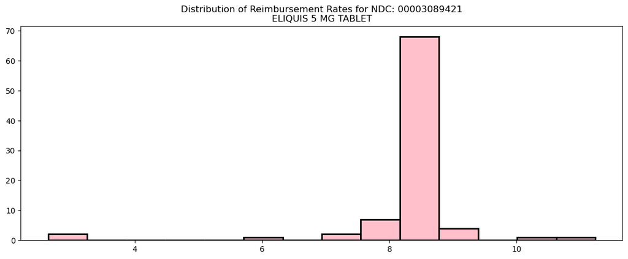

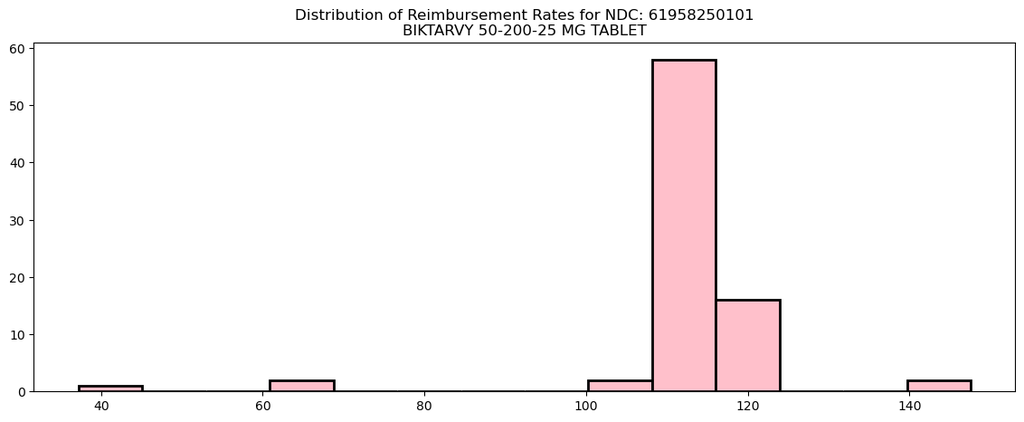

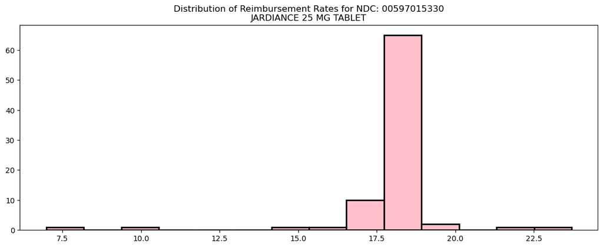

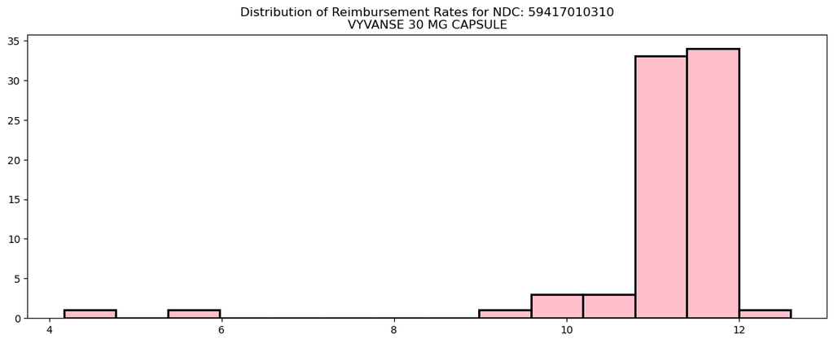

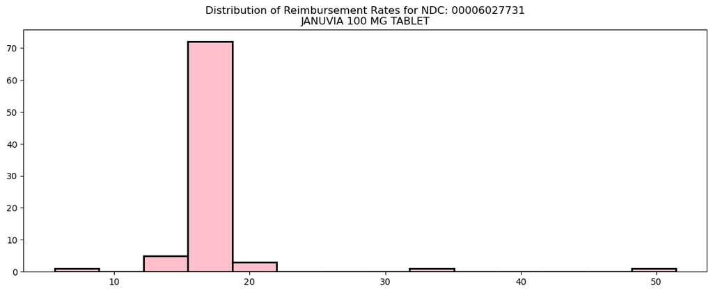

```python
plot_hist(top5_brand, 'pink')
```

```python
id_generic.head()
```

|  | state | ndc | quarter | product_name | units_reimbursed | number_of_prescriptions | total_amount_reimbursed | reimbursement_per_unit | drug | Pricing_Unit | OTC | Classification_for_Rate_Setting | z_score_reimburse_rate |
| --- | --- | --- | --- | --- | --- | --- | --- | --- | --- | --- | --- | --- | --- |
| 571987 | ID | 00228284903 | 1 | FLUVOXAMIN | 1230.0 | 34.0 | 5521.65 | 4.489146 | FLUVOXAMINE ER 150 MG CAPSULE | EA | N | G | -2.032277 |
| 572921 | ID | 00832107330 | 1 | TOPIRAMATE | 1101.0 | 31.0 | 18223.46 | 16.551735 | TOPIRAMATE ER 200 MG CAPSULE | EA | N | G | -1.806886 |
| 571986 | ID | 00228284803 | 1 | FLUVOXAMIN | 720.0 | 17.0 | 3499.66 | 4.860639 | FLUVOXAMINE ER 100 MG CAPSULE | EA | N | G | -1.721031 |
| 577273 | ID | 68180069806 | 1 | TRAMADOL H | 607.0 | 21.0 | 715.97 | 1.179522 | TRAMADOL HCL ER 200 MG TABLET | EA | N | G | -1.625879 |
| 573516 | ID | 16714090501 | 1 | VENLAFAXIN | 1290.0 | 37.0 | 1768.79 | 1.371155 | VENLAFAXINE HCL ER 150 MG TAB | EA | N | G | -1.606530 |

```python
# mean z-scores for all generic drugs in idaho
id_generic.z_score_reimburse_rate.describe()
```

```
count    4810.000000
mean        0.433145
std         0.768672
min        -2.032277
25%        -0.102201
50%         0.326109
75%         0.962876
max         6.150794
Name: z_score_reimburse_rate, dtype: float64
```

```python
id_brand.z_score_reimburse_rate.describe()
```

```
count    26994.000000
mean        -0.002592
std          0.635971
min         -2.574852
25%         -0.505900
50%         -0.090069
75%          0.465299
max          4.289461
Name: z_score_reimburse_rate, dtype: float64
```

```python
xx_generic.z_score_reimburse_rate.describe()
```

```
count    428.000000
mean       0.251075
std        0.464832
min       -2.975565
25%        0.056105
50%        0.215354
75%        0.410009
max        2.244897
Name: z_score_reimburse_rate, dtype: float64
```

```python
xx_brand.z_score_reimburse_rate.describe()
```

```
count    2346.000000
mean        0.005628
std         0.549793
min        -2.687981
25%        -0.230074
50%         0.041005
75%         0.253643
max         2.628893
Name: z_score_reimburse_rate, dtype: float64
```

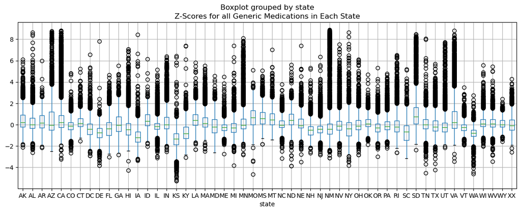

```python
generic.boxplot(by='state', column=['z_score_reimburse_rate'])
plt.title('Z-Scores for all Generic Medications in Each State')
```

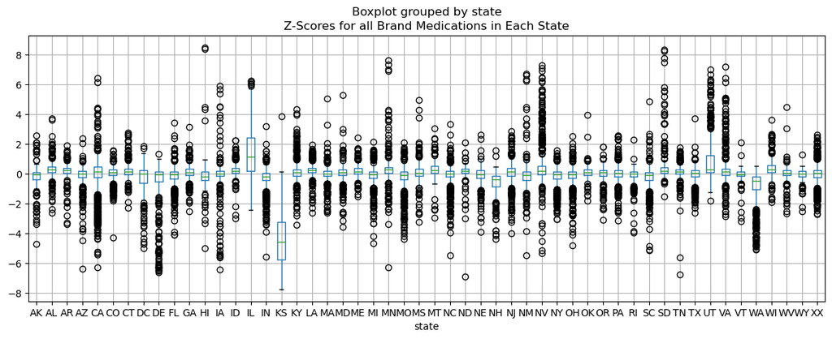

```python
brand.boxplot(by='state', column=['z_score_reimburse_rate'])
plt.title('Z-Scores for all Brand Medications in Each State')
```

```python
generic_z = [id_generic.z_score_reimburse_rate, xx_generic.z_score_reimburse_rate]
brand_z = [id_brand.z_score_reimburse_rate, xx_brand.z_score_reimburse_rate]
```

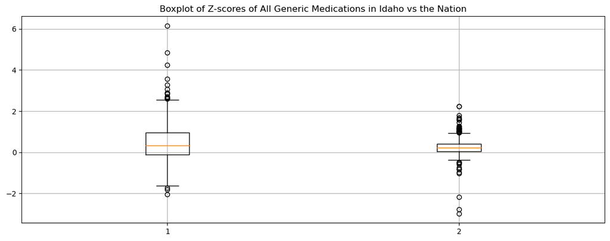

```python
plt.boxplot(generic_z)
plt.title('Boxplot of Z-scores of All Generic Medications in Idaho vs the Nation')
plt.grid()
plt.show()
```

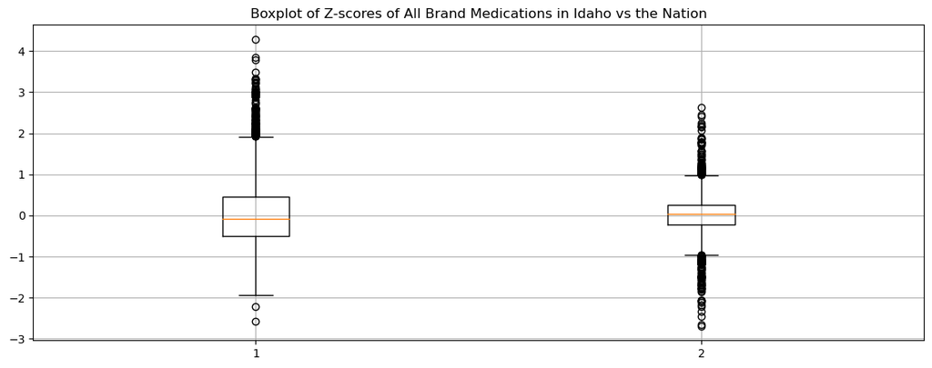

```python
plt.boxplot(brand_z)
plt.title('Boxplot of Z-scores of All Brand Medications in Idaho vs the Nation')
plt.grid()
plt.show()
```

```python
print(f'The mean Z-Score for Generic Reimbursement Rates in Idaho is:\n{id_generic.z_score_reimburse_rate.mean()}')
print(f'The mean Z-Score for Brand Reimbursement Rates in Idaho is:\n{id_brand.z_score_reimburse_rate.mean()}')
```

```
The mean Z-Score for Generic Reimbursement Rates in Idaho is:
0.4331446364058626
The mean Z-Score for Brand Reimbursement Rates in Idaho is:
-0.00259199281583188
```

Back to Top

## Conclusion

This analysis provided insights into the distribution of reimbursement rates across the nation. In the boxplot titled "Z-Scores for all Brand Medications in Each State", Kansas appears to have alarmingly low reimbursement rates. Other states may be able to benefit from similar analyses even though Idaho may not have directly benefited from it. Evidence exists to continue this study for other states.

Furthermore, the analysis could be useful for internal evaluation of a pharmacy's reimbursements compared to their state's average reimbursements. This could help a pharmacy root out procedural opportunities to optimize their billing practices to match their colleagues' best practices.

Back to Top

## Sources

- Ford, T., & Michener, J. (2022, June 16). Medicaid Reimbursement Rates Are a Racial Justice Issue. *The Commonwealth Fund*. Retrieved from https://www.commonwealthfund.org/blog/2022/medicaid-reimbursement-rates-are-racial-justice-issue
- “Pharmacy Groups Lobby for Revisions to Proposed Medicaid Rule” (2009, June 11). *Kaiser Health News*. Retrieved from https://kffhealthnews.org/morning-breakout/dr00045610/
- National Association of Chain Drug Stores v. Xavier Becerra, 2:21-cv-00576-RSM (W.D. Wash. filed April 29, 2021)
- DrugUtilization2022_updated.csv. Retrieved from https://data.medicaid.gov/dataset/200c2cba-e58d-4a95-aa60-14b99736808d/data
- nadac-national-average-drug-acquisition-cost-2022.csv. Retrieved from https://data.medicaid.gov/dataset/dfa2ab14-06c2-457a-9e36-5cb6d80f8d93